# projet_tnd_markdown

Anis Harmali

10/05/2020

# Partie 1 : Analyses descriptives

### 1) chargement du jeu de donnée

```r
cov_19 = read.csv2("donnes_covid19_avril_total_par_departement_GPS.csv")
```

### 2) présentation du jeu de données

```r
head(cov_19) # affichage partiel des données
```

```
##                maille_nom duree_jours latitude longitude deces_total
## 1                     Ain          15 46.24757  5.130768         431
## 2                   Aisne          15 49.47692  3.441737        1641
## 3                  Allier          15 46.31156  3.416765         138
## 4 Alpes-de-Haute-Provence          15 44.07787  6.237595          55
## 5         Alpes-Maritimes          15 43.94668  7.179026         766
## 6                ArdÃ¨che          15 44.75963  4.562443         472
##   reanimation_total hospitalises_total gueris_total
## 1               446               1691         1457
## 2               602               3563         3204
## 3               266                745          959
## 4                68                452          783
## 5              1088               3484         2939
## 6               282               1473         2249
```

```r
summary(cov_19) # vue résumée des variables
```

```
##                    maille_nom  duree_jours       latitude
##  Ain                    : 1   Min.   :15.00   Min.   :-21.12
##  Aisne                  : 1   1st Qu.:15.00   1st Qu.: 44.00
##  Allier                 : 1   Median :15.00   Median : 46.28
##  Alpes-de-Haute-Provence: 1   Mean   :15.42   Mean   : 43.78
##  Alpes-Maritimes        : 1   3rd Qu.:15.00   3rd Qu.: 48.34
##  ArdÃ¨che               : 1   Max.   :20.00   Max.   : 50.57
##  (Other)                :94
##    longitude           deces_total    reanimation_total hospitalises_total
##  Min.   :-106.12024   Min.   :    0   Min.   :   12.0   Min.   :  113.0
##  1st Qu.:  -0.03546   1st Qu.:  135   1st Qu.:  185.5   1st Qu.:  840.8
##  Median :   2.26503   Median :  355   Median :  410.5   Median : 1439.5
##  Mean   :  -4.61076   Mean   : 1047   Mean   : 1000.2   Mean   : 4357.9
##  3rd Qu.:   4.93254   3rd Qu.: 1016   3rd Qu.: 1069.0   3rd Qu.: 3819.5
##  Max.   :  55.53638   Max.   :10285   Max.   :12013.0   Max.   :45669.0
##
##   gueris_total
##  Min.   :   79.0
##  1st Qu.:  573.5
##  Median : 1166.0
##  Mean   : 2962.3
##  3rd Qu.: 3238.5
##  Max.   :23513.0
##
```

```r
library(FactoMineR,options(warn = -1))

names(cov_19) # nom des variables
```

```
## [1] "maille_nom"         "duree_jours"        "latitude"
## [4] "longitude"          "deces_total"        "reanimation_total"
## [7] "hospitalises_total" "gueris_total"
```

```r
str(cov_19) # type des variables
```

```
## 'data.frame':    100 obs. of  8 variables:
##  $ maille_nom        : Factor w/ 100 levels "Ain","Aisne",..: 1 2 3 4 5 6 7 8 9 10 ...
##  $ duree_jours       : int  15 15 15 15 15 15 15 16 15 16 ...
##  $ latitude          : num  46.2 49.5 46.3 44.1 43.9 ...
##  $ longitude         : num  5.13 3.44 3.42 6.24 7.18 ...
##  $ deces_total       : int  431 1641 138 55 766 472 118 13 618 478 ...
##  $ reanimation_total : int  446 602 266 68 1088 282 254 70 340 263 ...
##  $ hospitalises_total: int  1691 3563 745 452 3484 1473 1061 259 2536 1308 ...
##  $ gueris_total      : int  1457 3204 959 783 2939 2249 544 174 1371 1134 ...
```

```r
dim(cov_19) # dimension des données
```

```
## [1] 100   8
```

```r
library(dplyr,options(warn = -1))
```

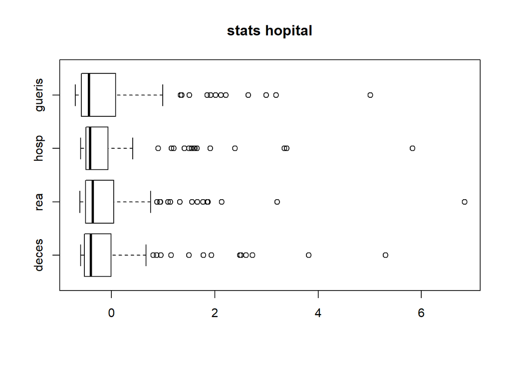

```r
boxplot(scale(cov_19[,5:8]), center = T, horizontal = T, main = "stats hopital",names=c("deces","rea","hosp","gueris")) # boite a moustache
```

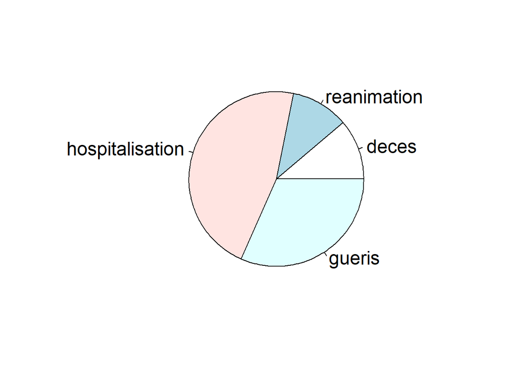

```r
moy_deces = mean(cov_19$deces_total)
moy_rea = mean(cov_19$reanimation_total)
moy_hosp = mean(cov_19$hospitalises_total)
moy_gueris = mean(cov_19$gueris_total)
# diagramme en secteur
pie(c(moy_deces,moy_rea,moy_hosp,moy_gueris),labels=c("deces","reanimation","hospitalisation","gueris"),cex=1.5)
```

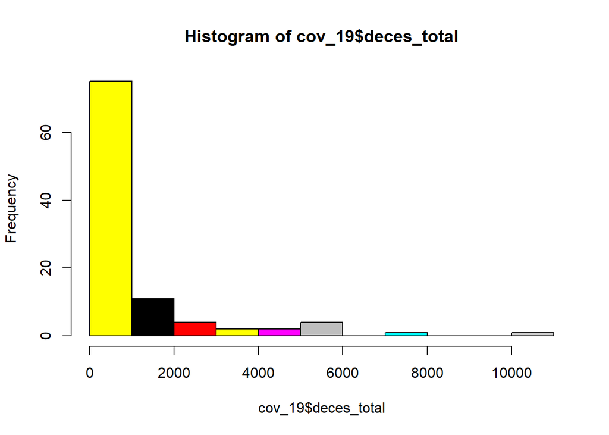

```r
# histogramme
hist(cov_19$deces_total,col = cov_19$deces_total)
```

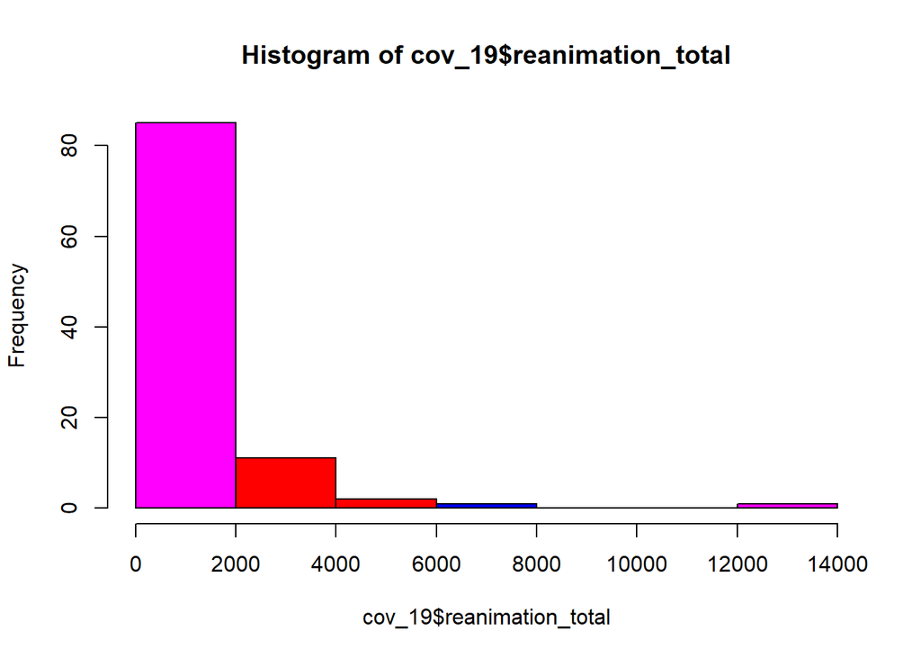

```r
hist(cov_19$reanimation_total,col = cov_19$reanimation_total)
```

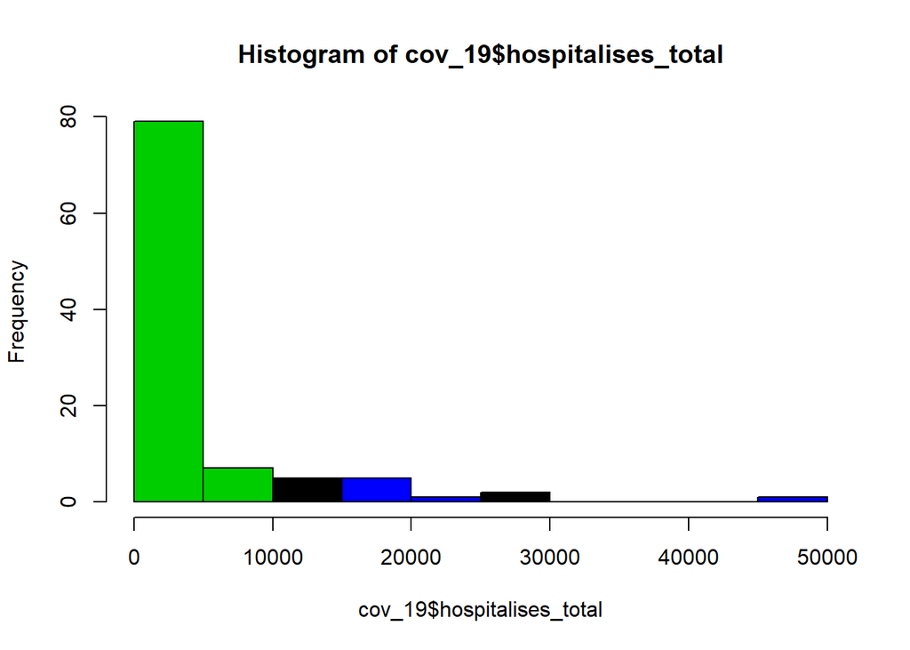

```r
hist(cov_19$hospitalises_total,col = cov_19$hospitalises_total)
```

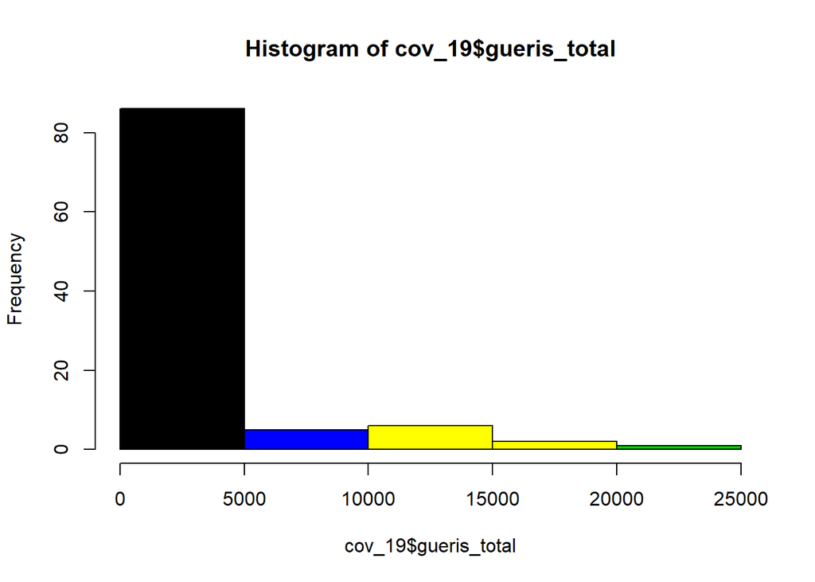

```r
hist(cov_19$gueris_total,col = cov_19$gueris_total)
```

### 3) affichage des données sur des cartes géographiques à partir de coordonnées GPS

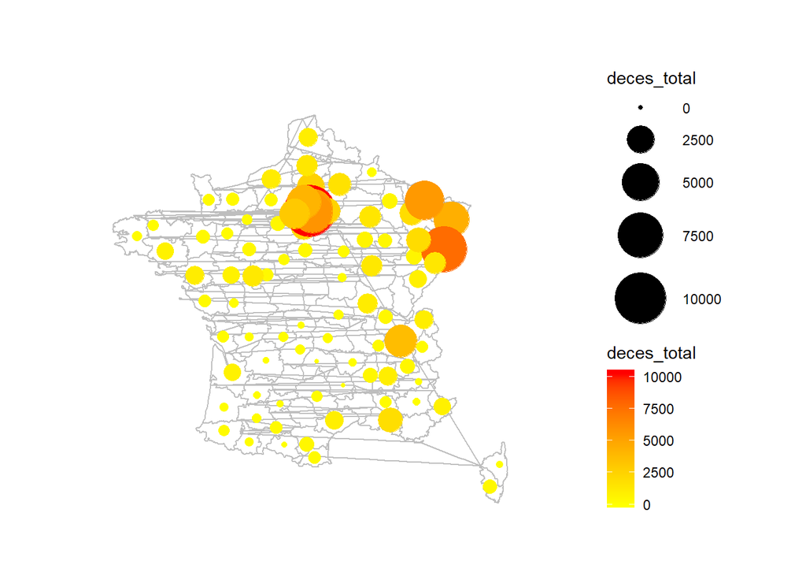

```r
library(ggplot2,options(warn = -1))
library(dplyr,options(warn = -1))
library(maps,options(warn = -1))
library(ggrepel,options(warn = -1))
library(mapdata,options(warn = -1))
library(viridis,options(warn = -1))
carte_fr <- map_data("france") #cree la carte de la france

# deces
ggplot(carte_fr, aes(x = long, y = lat)) +
  geom_polygon(data = carte_fr, fill="lightgray", colour = "grey", alpha=0)+
  geom_point( data = cov_19 , aes(x = longitude , y = latitude , size=deces_total,colour = deces_total))+
  scale_size_continuous(range=c(1,15)) +
  scale_color_gradient(low="yellow", high="red")+
  theme_void() +
  xlim (-5,12) + ylim(40,53) + coord_map()
```

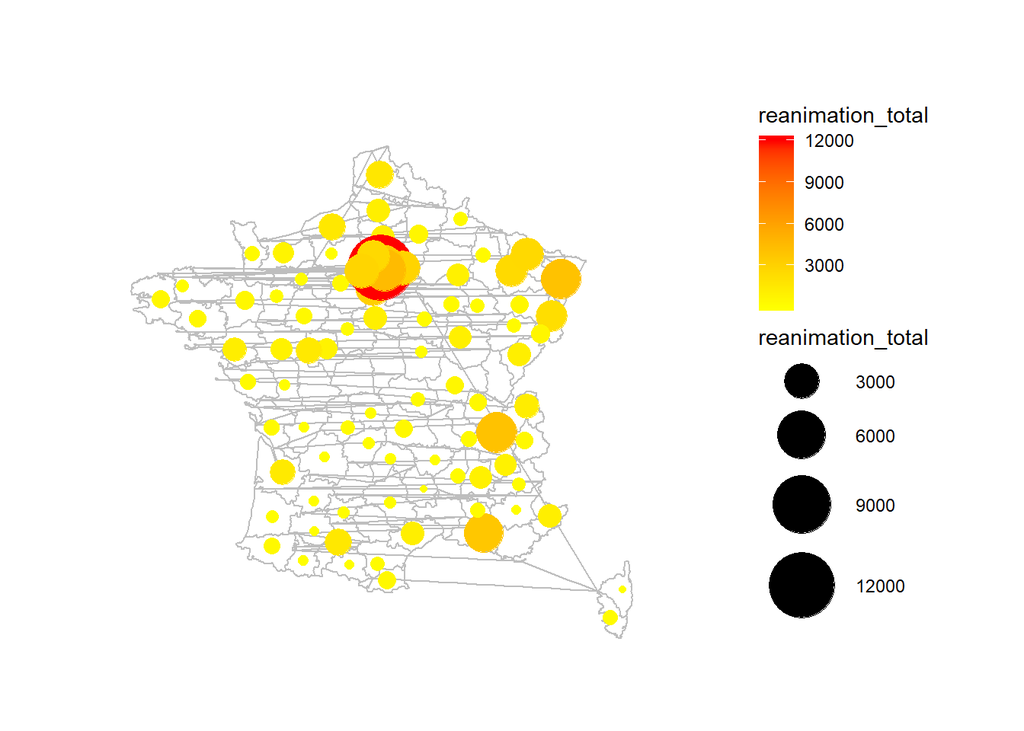

```r
# reanimation
ggplot(carte_fr, aes(x = long, y = lat)) +
  geom_polygon(data = carte_fr, fill="lightgray", colour = "grey", alpha=0)+
  geom_point( data = cov_19 , aes(x = longitude , y = latitude , size=reanimation_total,colour = reanimation_total))+
  scale_size_continuous(range=c(1,15)) +
  scale_color_gradient(low="yellow", high="red")+
  theme_void() +
  xlim (-5,12) + ylim(40,53) + coord_map()
```

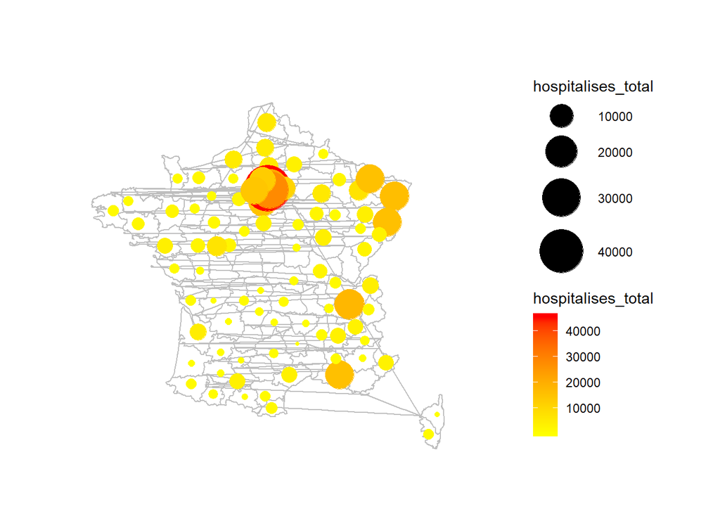

```r
# hospitalisation
ggplot(carte_fr, aes(x = long, y = lat)) +
  geom_polygon(data = carte_fr, fill="lightgray", colour = "grey", alpha=0)+
  geom_point( data = cov_19 , aes(x = longitude , y = latitude , size=hospitalises_total,colour = hospitalises_total))+
  scale_size_continuous(range=c(1,15)) +
  scale_color_gradient(low="yellow", high="red")+
  theme_void() +
  xlim (-5,12) + ylim(40,53) + coord_map()
```

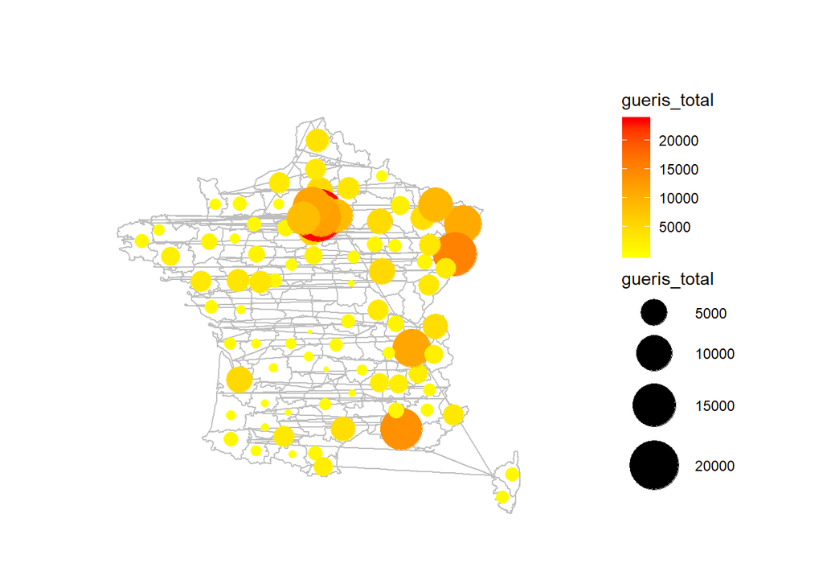

```r
# gueris
ggplot(carte_fr, aes(x = long, y = lat)) +
  geom_polygon(data = carte_fr, fill="lightgray", colour = "grey", alpha=0)+
  geom_point( data = cov_19 , aes(x = longitude , y = latitude , size=gueris_total,colour = gueris_total))+
  scale_size_continuous(range=c(1,15)) +
  scale_color_gradient(low="yellow", high="red")+
  theme_void() +
  xlim (-5,12) + ylim(40,53) + coord_map()
```

### 4) (Bonus) utilisation du package leaflet.minichart

```r
library(leaflet.minicharts,options(warn = -1))
library(leaflet,options(warn = -1))
tilesURL <- "https://{s}.tile.openstreetmap.fr/osmfr/{z}/{x}/{y}.png"
basemap <- leaflet(width = "100%", height = "600px") %>%addTiles(tilesURL)
```

carte des deces

```r
basemap %>%
  addMinicharts(
    cov_19$longitude, cov_19$latitude,
    chartdata = cov_19$deces_total,
    showLabels = TRUE,
    legend = T,
    width = 45,
  )
```

[interactive chart not shown]

carte des reanimations

```r
basemap %>%
  addMinicharts(
    cov_19$longitude, cov_19$latitude,
    chartdata = cov_19$reanimation_total,
    showLabels = TRUE,
    width = 45
  )
```

[interactive chart not shown]

carte des hospitalisations

```r
basemap %>%
  addMinicharts(
    cov_19$longitude, cov_19$latitude,
    chartdata = cov_19$hospitalises_total,
    showLabels = TRUE,
    width = 45
  )
```

[interactive chart not shown]

carte des gueris

```r
basemap %>%
  addMinicharts(
    cov_19$longitude, cov_19$latitude,
    chartdata = cov_19$gueris_total,
    showLabels = TRUE,
    colorPalette = colors,
    width = 45
  )
```

[interactive chart not shown]

# Partie 2 : Prédiction du nombre de décès

### 1) Calcul de la corrélation entre les différentes variables et afficher la matrice de corrélation

```r
library(corrplot,options(warn = -1))
correlation = cor(scale(cov_19[,5:8])) #calcule de la correlation
correlation # affichage
```

```
##                    deces_total reanimation_total hospitalises_total
## deces_total          1.0000000         0.8786039          0.9391129
## reanimation_total    0.8786039         1.0000000          0.9688570
## hospitalises_total   0.9391129         0.9688570          1.0000000
## gueris_total         0.9417929         0.9217680          0.9523850
##                    gueris_total
## deces_total           0.9417929
## reanimation_total     0.9217680
## hospitalises_total    0.9523850
## gueris_total          1.0000000
```

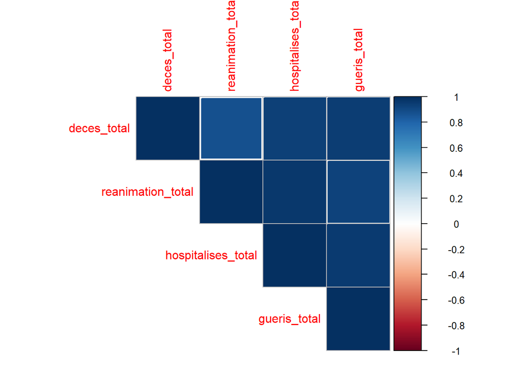

```r
corrplot(correlation,method = "square",type = "upper",addrect = 2,cl.ratio = 0.5,cl.cex = 0.8)
```

```r
# visualisation de la matrice de correaltion
```

### 2) Visualisation des nuages de points entre chaque variable et la variable à prédire «deces_total»

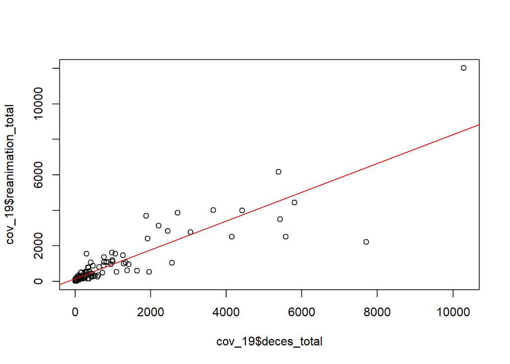

```r
plot(cov_19$deces_total,cov_19$reanimation_total)
droite = lm(cov_19$reanimation_total~cov_19$deces_total)
abline(droite,col = "red")
```

reanimation_total vs deces_total

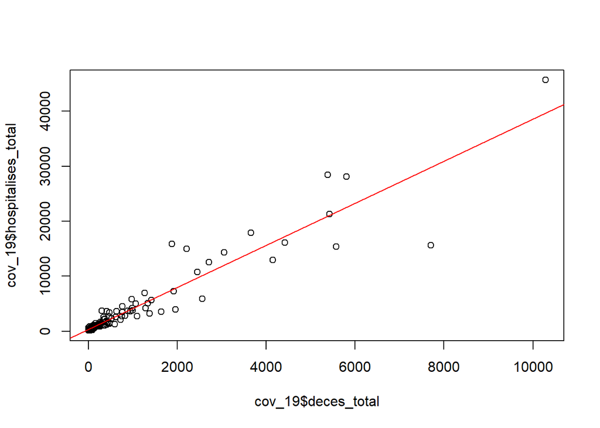

```r
plot(cov_19$deces_total,cov_19$hospitalises_total)
droite = lm(cov_19$hospitalises_total~cov_19$deces_total)
abline(droite,col = "red")
```

hospitalises_total vs deces_total

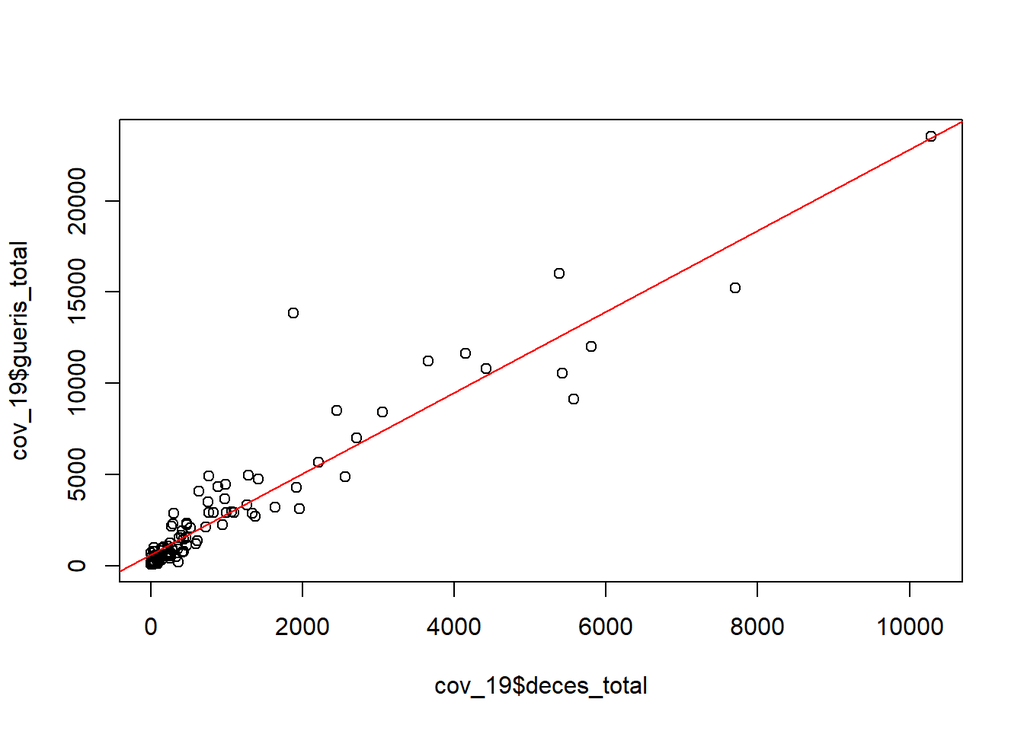

```r
plot(cov_19$deces_total,cov_19$gueris_total)
droite = lm(cov_19$gueris_total~cov_19$deces_total)
abline(droite,col = "red")
```

gueris_total vs deces_total

#Remarque: il y a une forte correclation entre toutes les variables

### 3) division du jeu de donnnées en deux ensembles apprentissage 80% /test 20%

```r
sample <- sample.int(n = nrow(cov_19), size = floor(.80*nrow(cov_19)))
apprentissage <- cov_19[sample, ]
test  <- cov_19[-sample, ]
```

### 4) Réalisation d’une régression linéaire entre les variables explicatives «reanimation_total»,«hospitalises_total»,«gueris_total» et la variable à expliquer «deces_total» surl’ensembled’apprentissage

```r
# calcule de la regression multiple
regression_apprentissage = lm(deces_total ~ reanimation_total+hospitalises_total+gueris_total,data=apprentissage)
summary(regression_apprentissage)
```

```
##
## Call:
## lm(formula = deces_total ~ reanimation_total + hospitalises_total +
##     gueris_total, data = apprentissage)
##
## Residuals:
##      Min       1Q   Median       3Q      Max
## -2334.71  -162.69   -34.04   131.21  1398.10
##
## Coefficients:
##                    Estimate Std. Error t value Pr(>|t|)
## (Intercept)        62.55939   67.65564   0.925    0.358
## reanimation_total  -1.31605    0.19399  -6.784 2.23e-09 ***
## hospitalises_total  0.36250    0.05464   6.634 4.26e-09 ***
## gueris_total        0.23551    0.04697   5.014 3.40e-06 ***
## ---
## Signif. codes:  0 '***' 0.001 '**' 0.01 '*' 0.05 '.' 0.1 ' ' 1
##
## Residual standard error: 464.3 on 76 degrees of freedom
## Multiple R-squared:  0.8981, Adjusted R-squared:  0.8941
## F-statistic: 223.3 on 3 and 76 DF,  p-value: < 2.2e-16
```

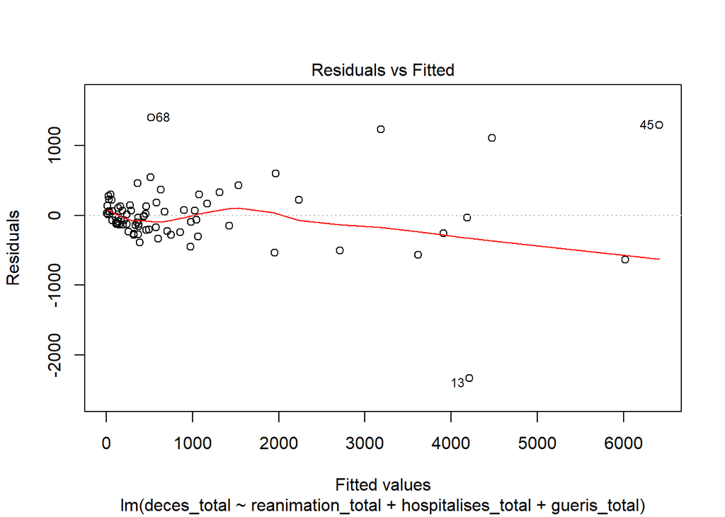

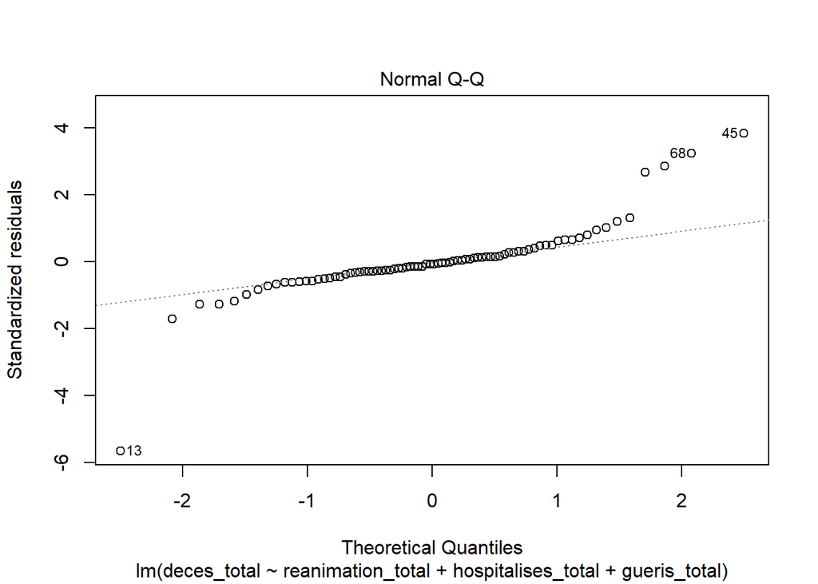

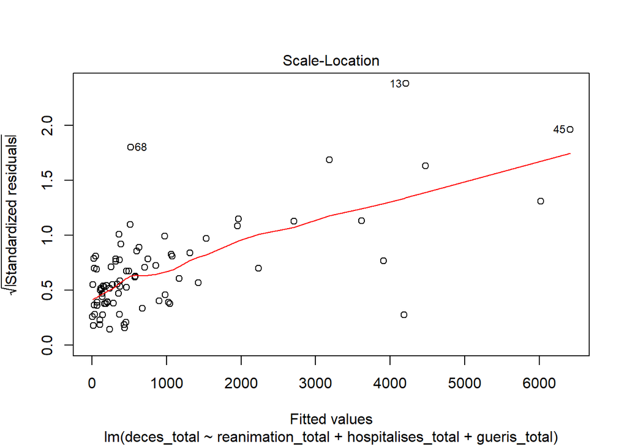

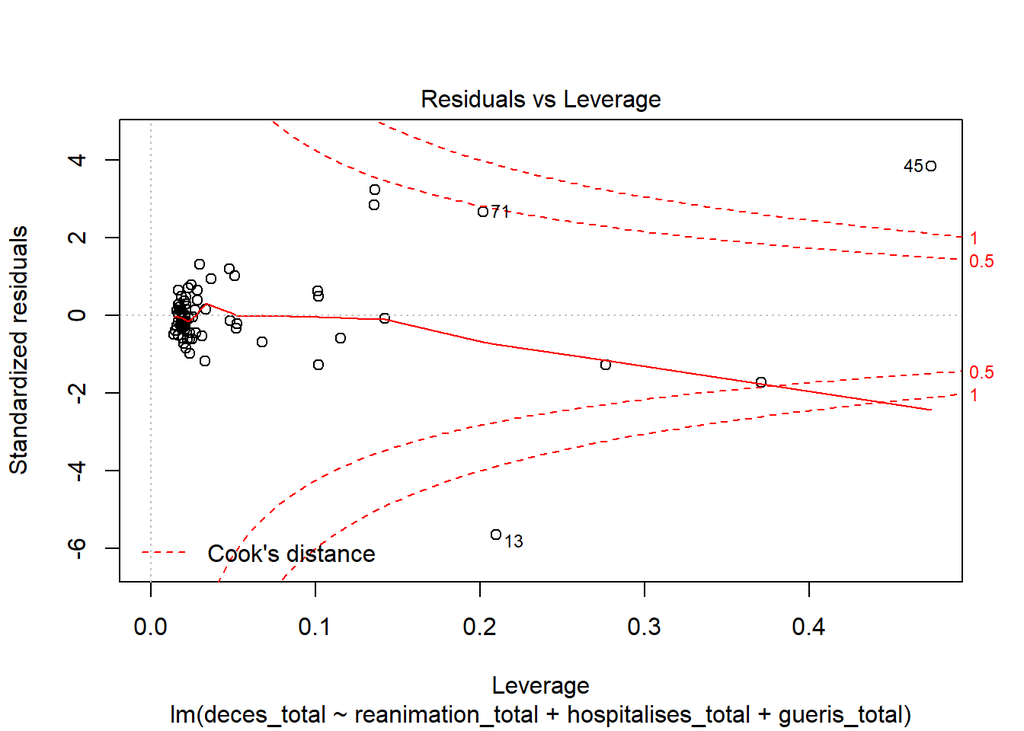

```r
#Affichage des quatre graphiques de diagnostic.
plot(regression_apprentissage)
```

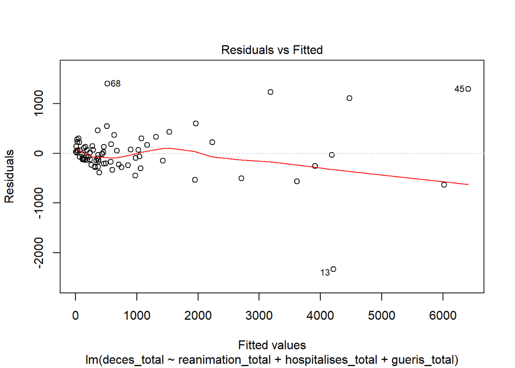

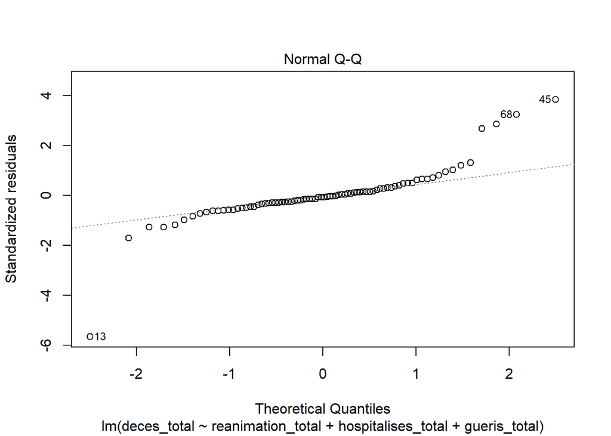

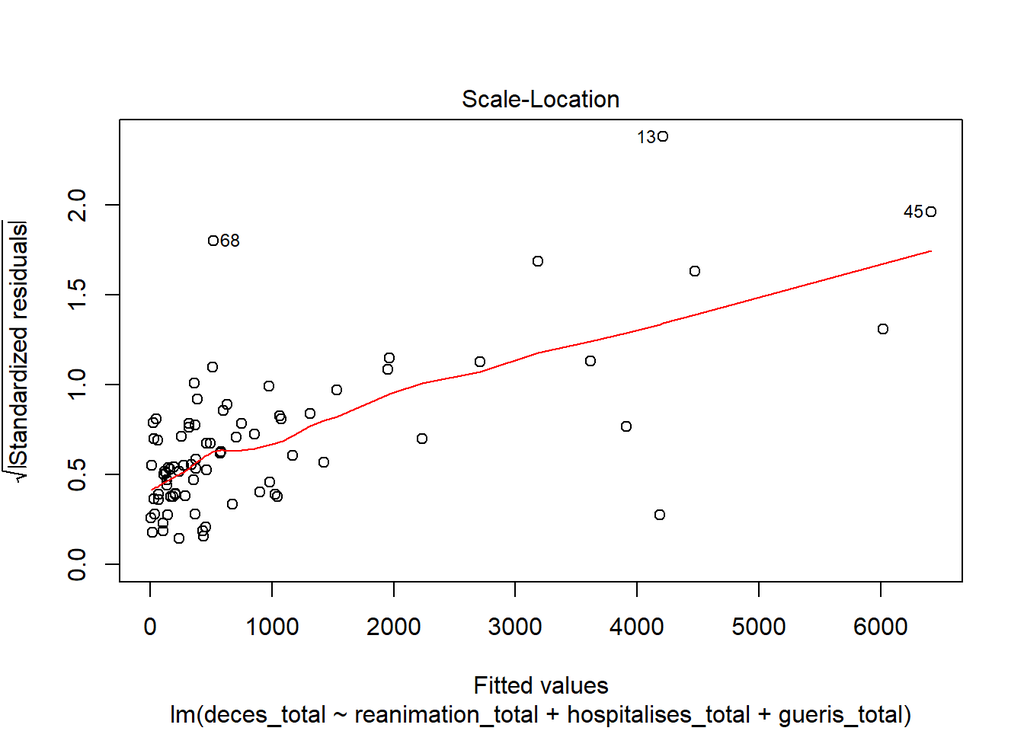

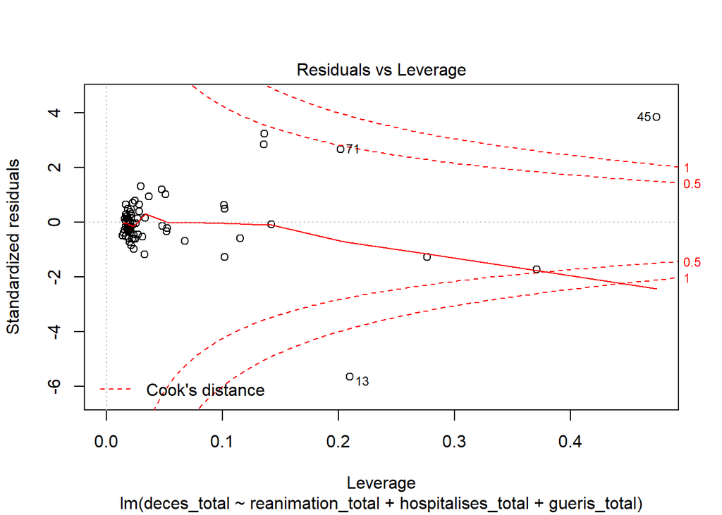

```r
apprentissage=  apprentissage[apprentissage$maille_nom != "Paris",]
regression_apprentissage = lm(deces_total~reanimation_total+hospitalises_total+gueris_total,data=apprentissage) # on retire Paris (point)
plot(regression_apprentissage)
```

### 5) commenter les resultat obtenus ( coef de régressions de chaque variable)

```r
coef(regression_apprentissage)
```

```
##        (Intercept)  reanimation_total hospitalises_total       gueris_total
##         62.5593908         -1.3160477          0.3625038          0.2355056
```

#les coefficients ne sont pas nuls ce qui implique qu’ils ont tous un effet sur le modèle mais pas très persistant vu qu’il y’a une redandance comme nous avons pu le voir pour la correlation, don un modèle à 1 ou à 2 variables aurait largement suffit

### 6) Calculer les erreurs MAE (Mean Absolute Error) et MSE (Mean Squared Error)

fonction de calcul de la MAE et de la MSE

```r
MAE <- function(y_reel, y_est){
  val = abs(y_reel-y_est)
  mae_cal = mean(val)
  return(mae_cal)

}

MSE <- function(y_reel, y_est){
  val = (y_reel-y_est)^2
  mse_cal = mean(val)
  return(mse_cal)

}
```

calcul sur l’ensemble d’apprentissage

```r
y_estime = predict(regression_apprentissage)

MAE_appprentissage = MAE(apprentissage$deces_total,y_estime)
MAE_appprentissage
```

```
## [1] 270.8674
```

```r
MSE_apprentissage = MSE(apprentissage$deces_total,y_estime)
MSE_apprentissage
```

```
## [1] 204824.3
```

calcul sur l’ensemble de test

```r
regression_test = lm(deces_total~reanimation_total+hospitalises_total+gueris_total,data=test)
y_estime_test = predict(regression_test)

MAE_test = MAE(test$deces_total,y_estime)
MAE_test
```

```
## [1] 1720.903
```

```r
MSE_test = MSE(test$deces_total,y_estime)
MSE_test
```

```
## [1] 9280940
```

# Partie 3 : Clustering des départements selon la dynamique de propagation du virus

1. réalisation d’une ACP

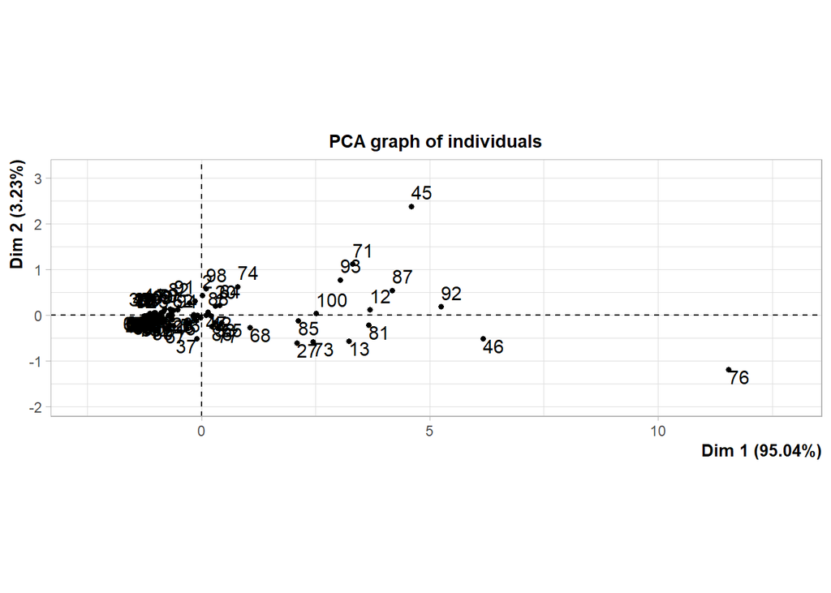

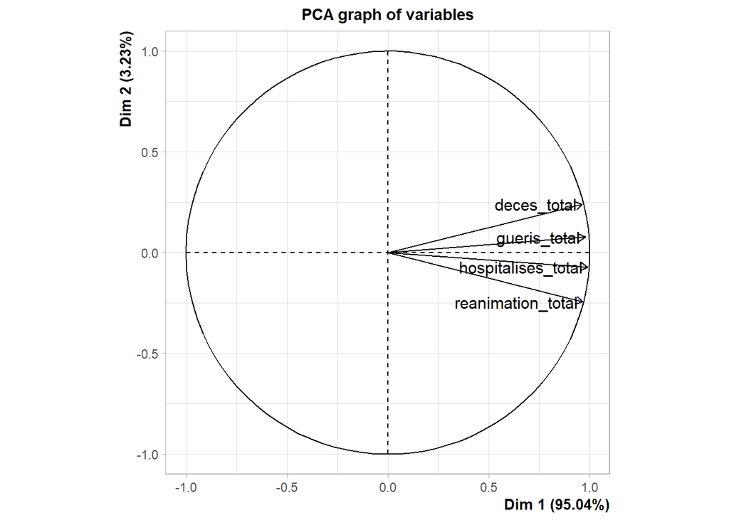

```r
pca = PCA(cov_19[,5:8])
```

#cercle de correlation : les lignes ont toutes la même portée donc une correlation positive entre elles et vu que l’angle qui sépare les variables est tres faible, les tangentes sont plutot faibles

#nuage des individus : ici on remarque que 76 est une observation a rejeter car elle se situe loin de la zone de confiance, donc elle est probablement erronée

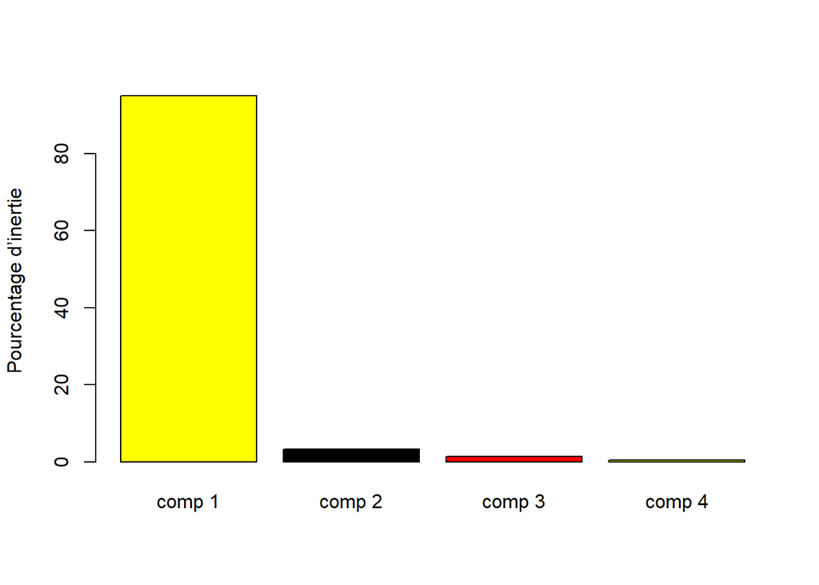

```r
barplot(pca$eig[,2],ylab= "Pourcentage d’inertie",col= cov_19$deces_total)
```

```r
# La composante 1 ramene 95 % de variance, les autres composantes ont une variance iferieur a 100/4 = 25 %
```

### 2) projection des individus (les départements) dans le plan d’inertie maximum et les colorier en utilisant la variable «deces_total»

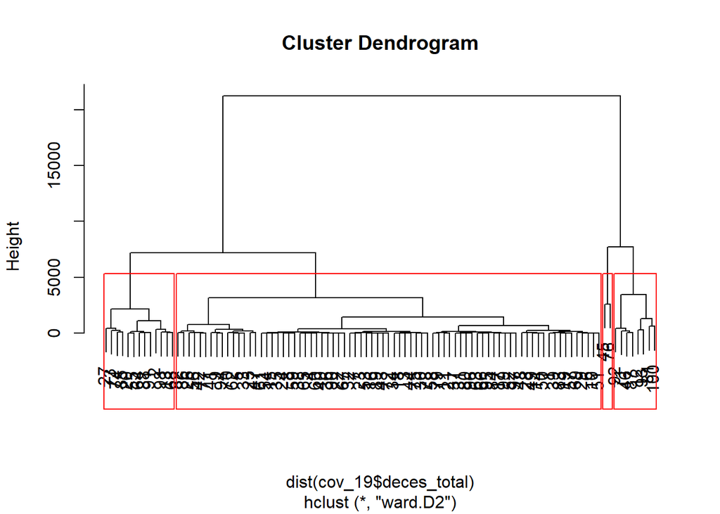

```r
dd.hclust <- hclust(dist(cov_19$deces_total), method = "ward.D2")
plot(dd.hclust)
rect.hclust(dd.hclust, h = 5000) # afin de partitionner
```

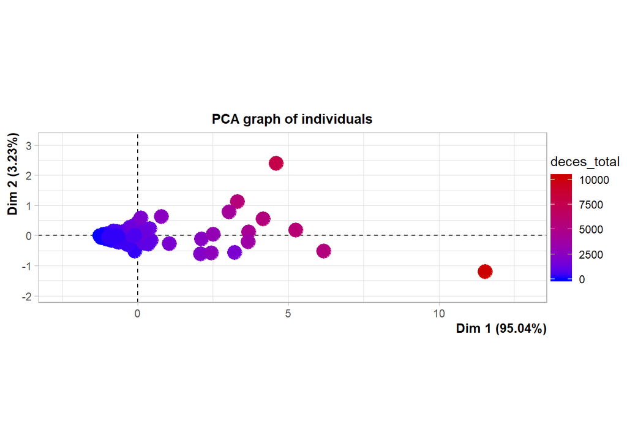

```r
partition <- cutree(dd.hclust, h= 5000)

plot(pca,label = "quali", cex=4,habillage = 1 )
```

#Au debut la classification est homogène pour les departements dont le nombre de deces est faible mais pour les autres ils sont trés rapprochés

### 3) classifications non-supervisées (clustering)

K-means

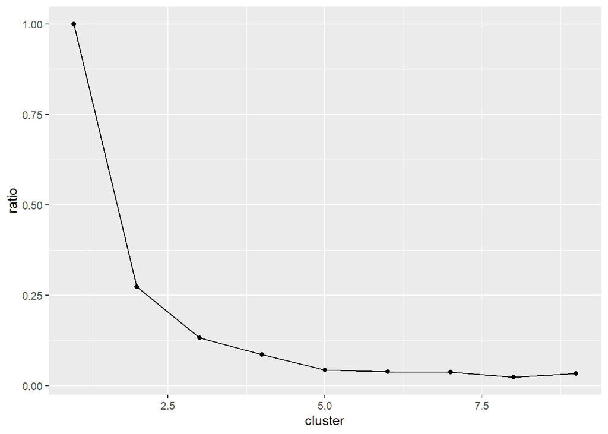

```r
ratio_ss <- data.frame(cluster = seq(from = 1, to = 9, by = 1))
for (k in 1:9) {
  km_model <- kmeans(cov_19[,(5:8)], k, nstart = 20)
  ratio_ss$ratio[k] <- km_model$tot.withinss / km_model$totss
}

ggplot(ratio_ss, aes(cluster, ratio)) +
  geom_line() +
  geom_point()
```

#Nous voyons donc que le nombre de clusters idéal pour notre jeu de données se situe entre 3 et 5 (critere du coude), a partir de la nous choissisant 4 comme nombre de classes

```r
library(factoextra,options(warn = -1))
kmean_res = kmeans(cov_19[,5:8],centers = 4, nstart=20)
kmean_res$size
```

```
## [1] 62 24  3 11
```

```r
kmean_res$centers
```

```
##   deces_total reanimation_total hospitalises_total gueris_total
## 1    214.9032          256.6129           1028.161     796.5968
## 2   1110.8333         1102.9167           4258.750    3465.0833
## 3   7157.6667         7540.6667          34054.667   17192.0000
## 4   3929.7273         3183.7273          15243.091   10191.4545
```

```r
kmean_res$cluster
```

```
##   [1] 1 2 1 1 2 1 1 1 1 1 1 4 4 1 1 1 1 1 1 2 1 1 1 1 2 2 4 1 1 1 1 1 2 1 1 1 2
##  [38] 1 1 1 1 2 1 1 4 3 2 1 1 1 2 1 1 1 2 2 2 1 1 1 1 2 1 2 1 1 1 2 1 1 4 1 4 2
##  [75] 1 3 2 1 1 1 4 2 1 1 4 2 4 2 1 1 2 3 4 2 1 1 1 2 1 4
```

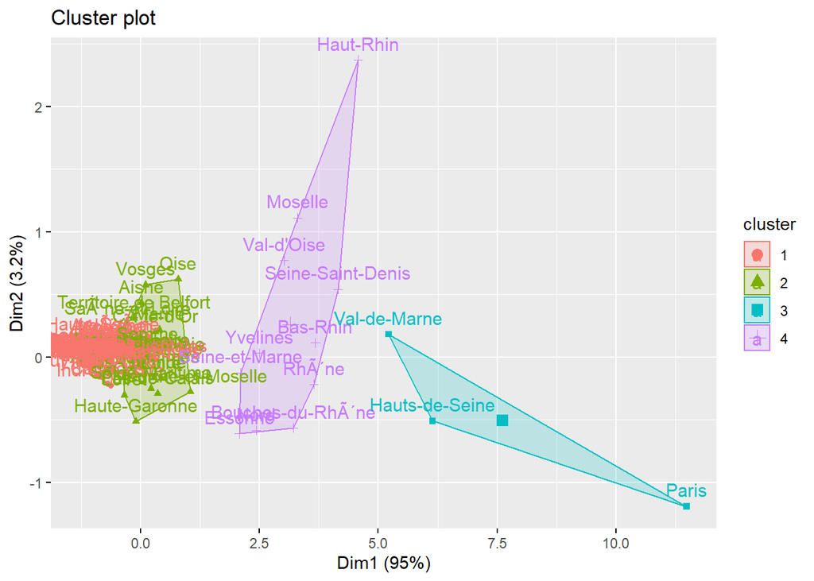

```r
cov_19.cr= scale (cov_19[,5:8] ,center = T,scale = T)
row.names(cov_19.cr)=cov_19[,1]
fviz_cluster(kmean_res, data = cov_19.cr )
```

CAH avec les 4 critères

```r
cov_19_prep = cov_19[,5:8]

# matrice de distance (euclidienne)
row.names(cov_19_prep)=cov_19[,1]
distance = dist(cov_19_prep, method = "euclidean")
```

CAH lien minimum

```r
my_clust_1 = hclust(distance*distance, method  = "single")
my_classe_1 = cutree(my_clust_1,k = 4)
```

CAH lien moyen

```r
my_clust_2 = hclust(distance*distance, method  = "average")
my_classe_2 = cutree(my_clust_2,k = 4)
```

CAH lien maximum

```r
my_clust_3 = hclust(distance*distance, method  = "complete")
my_classe_3 = cutree(my_clust_3,k = 4)
```

Ward

```r
my_clust_4 = hclust(distance*distance, method  = "ward.D")
my_classe_4 = cutree(my_clust_4,k = 4)
```

### 4) étude comparative entre les résultats des différents algorithmes sous forme d’un tableau.

```r
cah_min_size = table(as.factor(my_classe_1))
cah_moy_size = table(as.factor(my_classe_2))
cah_max_size = table(as.factor(my_classe_3))
cah_ward_size = table(as.factor(my_classe_4))
compar_table = rbind(cah_min_size,cah_moy_size,cah_max_size,cah_ward_size,kmean_res$size)
row.names(compar_table)=c("minimum","moyen","maximum","ward","kmeans")
colnames(compar_table)=c("my_classe_1","my_classe_2","my_classe_3","my_classe_4")
compar_table
```

```
##         my_classe_1 my_classe_2 my_classe_3 my_classe_4
## minimum          96           1           2           1
## moyen            86          11           2           1
## maximum          86          11           2           1
## ward             62          24          11           3
## kmeans           62          24           3          11
```

#la repartition des valeurs suivant ward et kmeans semble meilleure que les 3 autres. En effet la repartition de ces dernieres ce fait essentiellement sur la classe 1

Projection des groupes obtenus par chaque méthodes (clusters) sur le nuage des individus

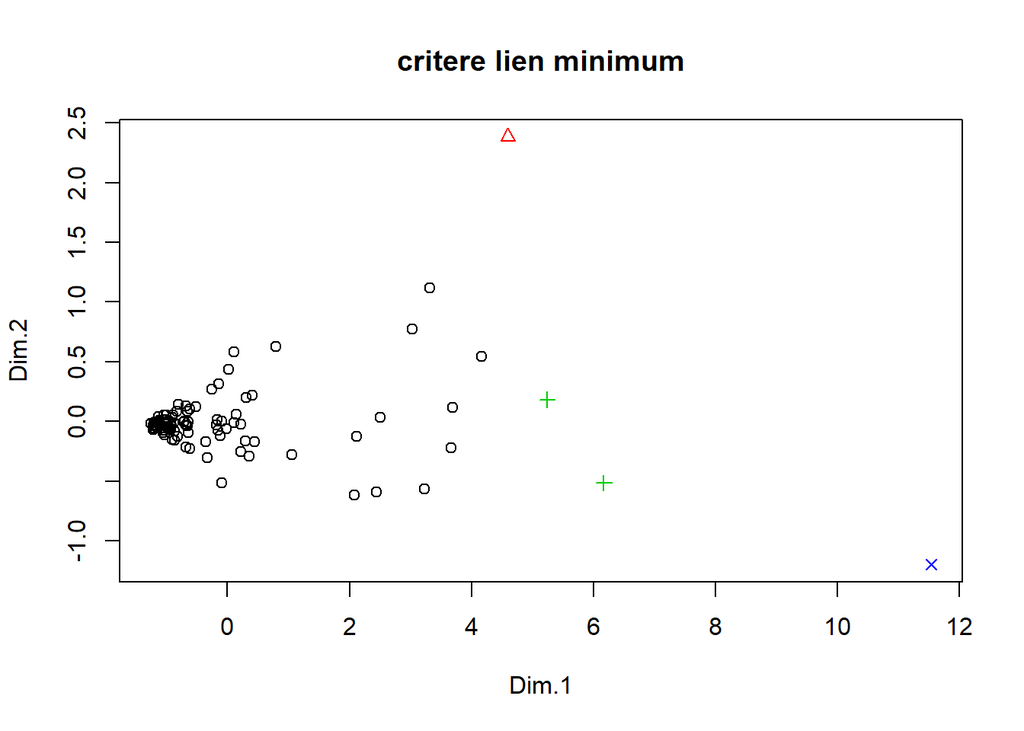

```r
plot(pca$ind$coord,col = my_classe_1,pch = my_classe_1,main = "critere lien minimum")
```

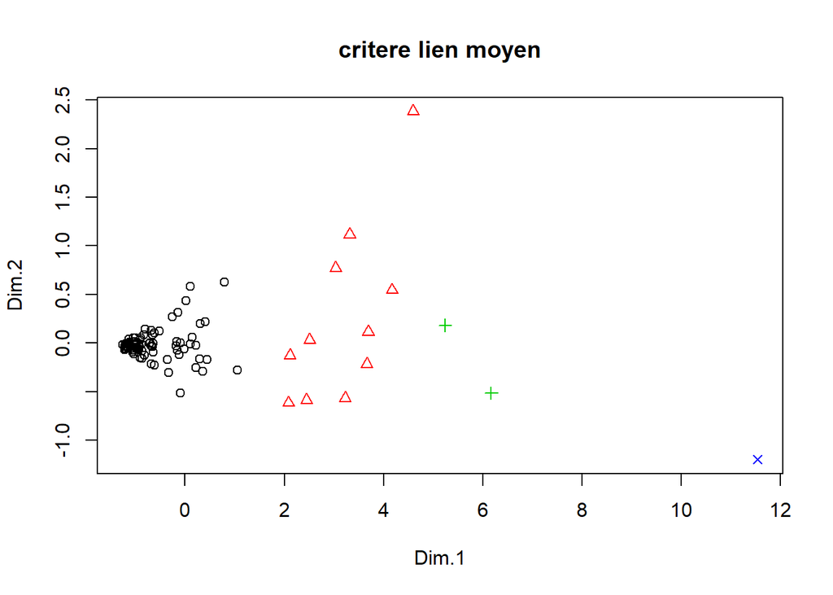

```r
plot(pca$ind$coord,col = my_classe_2,pch = my_classe_2,main = "critere lien moyen")
```

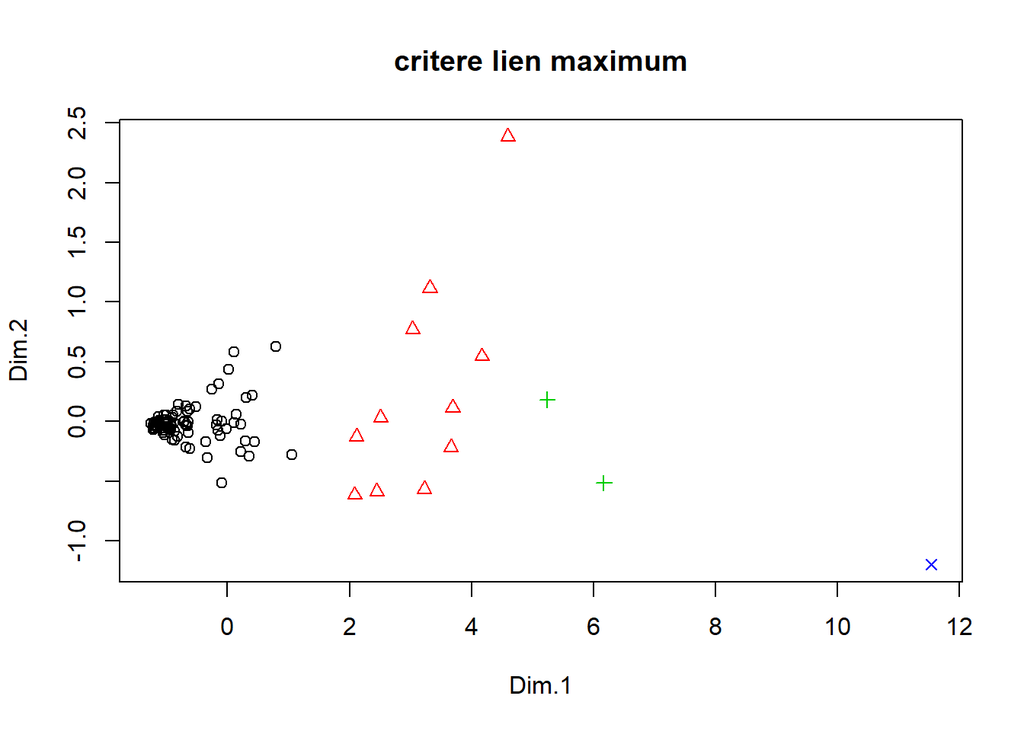

```r
plot(pca$ind$coord,col = my_classe_3,pch = my_classe_3,main = "critere lien maximum")
```